# PML_FinalProject

Fabrizio

July 10, 2016

# Prediction project for the Practical Machine Learning course

One thing that people regularly do is quantify how much of a particular activity they do, but they rarely quantify how well they do it. In this project, your goal will be to use data from accelerometers on the belt, forearm, arm, and dumbell of 6 participants. The goal of your project is to predict the manner in which they did the exercise.

The “classe” variable contains 5 levels: A,B,C,D,E. You may use any of the other variables to predict with. You should create a report describing 1) how you built your model 2) how you used cross validation 3) what you think the expected out of sample error is 4) and why you made the choices you did. 5) you will also use your prediction model to predict 20 different test cases.

## Load packages

```r
suppressPackageStartupMessages(library(caret))
```

```r
suppressPackageStartupMessages(library(corrplot))
```

```r
training <- read.csv("pml-training.csv")
testing  <- read.csv("pml-testing.csv")
filter = grepl("belt|arm|dumbell|classe", names(training))
training = training[, filter]
testing = testing[, filter]
cols.without.na = colSums(is.na(testing)) == 0
training = training[, cols.without.na]
testing = testing[, cols.without.na]
```

## Preprocessing

Trasnform “classe” in a numeric column. Check zero variance predictors.

```r
num.class = length(levels(training$classe))
levels(training$classe) = 1:num.class
head(training)
```

```
##   roll_belt pitch_belt yaw_belt total_accel_belt gyros_belt_x gyros_belt_y
## 1      1.41       8.07    -94.4                3         0.00         0.00
## 2      1.41       8.07    -94.4                3         0.02         0.00
## 3      1.42       8.07    -94.4                3         0.00         0.00
## 4      1.48       8.05    -94.4                3         0.02         0.00
## 5      1.48       8.07    -94.4                3         0.02         0.02
## 6      1.45       8.06    -94.4                3         0.02         0.00
##   gyros_belt_z accel_belt_x accel_belt_y accel_belt_z magnet_belt_x
## 1        -0.02          -21            4           22            -3
## 2        -0.02          -22            4           22            -7
## 3        -0.02          -20            5           23            -2
## 4        -0.03          -22            3           21            -6
## 5        -0.02          -21            2           24            -6
## 6        -0.02          -21            4           21             0
##   magnet_belt_y magnet_belt_z roll_arm pitch_arm yaw_arm total_accel_arm
```

[output cut: 41 more lines]

```r
zero.var = nearZeroVar(training, saveMetrics=TRUE)
zero.var
```

```
##                     freqRatio percentUnique zeroVar   nzv
## roll_belt            1.101904     6.7781062   FALSE FALSE
## pitch_belt           1.036082     9.3772296   FALSE FALSE
## yaw_belt             1.058480     9.9734991   FALSE FALSE
## total_accel_belt     1.063160     0.1477933   FALSE FALSE
## gyros_belt_x         1.058651     0.7134849   FALSE FALSE
## gyros_belt_y         1.144000     0.3516461   FALSE FALSE
## gyros_belt_z         1.066214     0.8612782   FALSE FALSE
## accel_belt_x         1.055412     0.8357966   FALSE FALSE
## accel_belt_y         1.113725     0.7287738   FALSE FALSE
## accel_belt_z         1.078767     1.5237998   FALSE FALSE
## magnet_belt_x        1.090141     1.6664968   FALSE FALSE
## magnet_belt_y        1.099688     1.5187035   FALSE FALSE
## magnet_belt_z        1.006369     2.3290184   FALSE FALSE
## roll_arm            52.338462    13.5256345   FALSE FALSE
## pitch_arm           87.256410    15.7323412   FALSE FALSE
## yaw_arm             33.029126    14.6570176   FALSE FALSE
## total_accel_arm      1.024526     0.3363572   FALSE FALSE
## gyros_arm_x          1.015504     3.2769341   FALSE FALSE
## gyros_arm_y          1.454369     1.9162165   FALSE FALSE
## gyros_arm_z          1.110687     1.2638875   FALSE FALSE
## accel_arm_x          1.017341     3.9598410   FALSE FALSE
## accel_arm_y          1.140187     2.7367241   FALSE FALSE
## accel_arm_z          1.128000     4.0362858   FALSE FALSE
## magnet_arm_x         1.000000     6.8239731   FALSE FALSE
## magnet_arm_y         1.056818     4.4439914   FALSE FALSE
## magnet_arm_z         1.036364     6.4468454   FALSE FALSE
## roll_forearm        11.589286    11.0895933   FALSE FALSE
## pitch_forearm       65.983051    14.8557741   FALSE FALSE
## yaw_forearm         15.322835    10.1467740   FALSE FALSE
## total_accel_forearm  1.128928     0.3567424   FALSE FALSE
## gyros_forearm_x      1.059273     1.5187035   FALSE FALSE
## gyros_forearm_y      1.036554     3.7763735   FALSE FALSE
## gyros_forearm_z      1.122917     1.5645704   FALSE FALSE
## accel_forearm_x      1.126437     4.0464784   FALSE FALSE
## accel_forearm_y      1.059406     5.1116094   FALSE FALSE
## accel_forearm_z      1.006250     2.9558659   FALSE FALSE
## magnet_forearm_x     1.012346     7.7667924   FALSE FALSE
## magnet_forearm_y     1.246914     9.5403119   FALSE FALSE
## magnet_forearm_z     1.000000     8.5771073   FALSE FALSE
## classe               1.469581     0.0254816   FALSE FALSE
```

Now create a cross-validation sample that will be used to estimate the out-of-sample error

```r
inTrain <- createDataPartition(training$classe, p = 0.6, list = FALSE)
training <- training[inTrain, ]
validate <- training[-inTrain,]
```

## A Boosted Decision Tree model

Now create a model training it on the 60% of the dataset provided in the project, using boosted decision trees. Checking also the importance of the predictors.

```r
boostFit <- train(classe ~ ., method = "gbm", data = training, verbose = F, trControl = trainControl(method = "cv", number = 10))
boostFit
```

```
## Stochastic Gradient Boosting
##
## 11776 samples
##    39 predictor
##     5 classes: '1', '2', '3', '4', '5'
##
## No pre-processing
## Resampling: Cross-Validated (10 fold)
## Summary of sample sizes: 10599, 10599, 10598, 10599, 10600, 10598, ...
## Resampling results across tuning parameters:
##
##   interaction.depth  n.trees  Accuracy   Kappa      Accuracy SD
##   1                   50      0.6997260  0.6191504  0.009707909
##   1                  100      0.7613776  0.6980386  0.010897919
##   1                  150      0.7981484  0.7447777  0.008805739
##   2                   50      0.8070676  0.7560094  0.012088996
##   2                  100      0.8646445  0.8288209  0.009674537
##   2                  150      0.8984388  0.8714892  0.005315984
##   3                   50      0.8633655  0.8272216  0.009371881
##   3                  100      0.9128758  0.8897319  0.005713676
##   3                  150      0.9359721  0.9189666  0.005027940
##   Kappa SD
##   0.012159080
##   0.014085974
##   0.011260456
##   0.015391711
##   0.012270817
##   0.006825091
##   0.011938857
##   0.007308302
##   0.006406122
##
## Tuning parameter 'shrinkage' was held constant at a value of 0.1
##
## Tuning parameter 'n.minobsinnode' was held constant at a value of 10
## Accuracy was used to select the optimal model using  the largest value.
## The final values used for the model were n.trees = 150,
##  interaction.depth = 3, shrinkage = 0.1 and n.minobsinnode = 10.
```

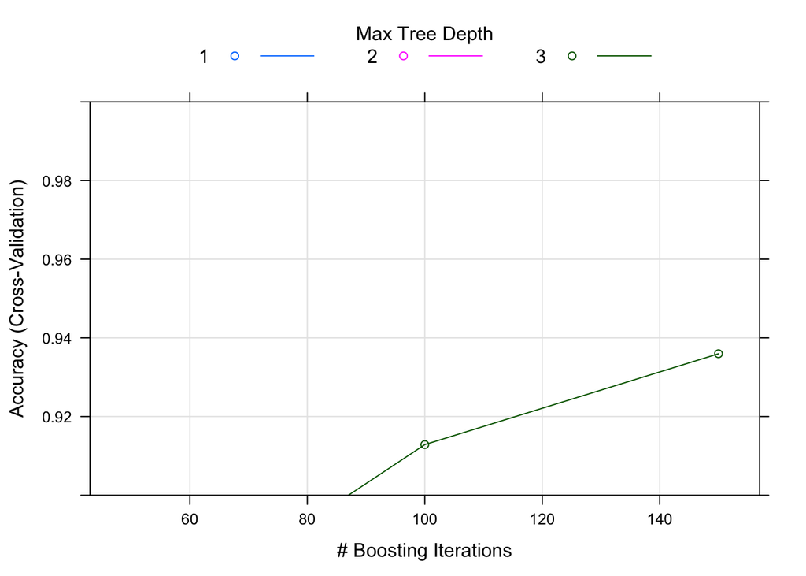

```r
plot(boostFit, ylim = c(0.9, 1))
```

```r
imp <- varImp(boostFit)$importance
imp$max <- apply(imp, 1, max)
imp <- imp[order(imp$max, decreasing = T), ]
imp
```

```
##                         Overall         max
## roll_belt           100.0000000 100.0000000
## pitch_forearm        53.5985047  53.5985047
## yaw_belt             52.2279856  52.2279856
## pitch_belt           36.6810664  36.6810664
## roll_forearm         27.5643159  27.5643159
## accel_forearm_x      18.0410658  18.0410658
## accel_forearm_z      15.0286874  15.0286874
## magnet_belt_z        13.6819794  13.6819794
## magnet_arm_z         11.6350673  11.6350673
## gyros_belt_z         11.5990512  11.5990512
## magnet_forearm_z     10.2031729  10.2031729
## yaw_arm               8.4591070   8.4591070
## roll_arm              7.5415541   7.5415541
## magnet_arm_x          5.5843965   5.5843965
## magnet_belt_x         5.2159883   5.2159883
## magnet_belt_y         5.0109991   5.0109991
## total_accel_forearm   4.9133966   4.9133966
## accel_belt_z          4.8817808   4.8817808
## gyros_arm_y           4.3232414   4.3232414
## magnet_arm_y          4.2004354   4.2004354
## magnet_forearm_y      3.0845631   3.0845631
## magnet_forearm_x      3.0546734   3.0546734
## gyros_belt_y          2.5806616   2.5806616
## gyros_forearm_z       2.4787329   2.4787329
## accel_forearm_y       2.2527773   2.2527773
## accel_arm_x           1.3202596   1.3202596
## total_accel_arm       1.1503374   1.1503374
## accel_arm_z           0.8722134   0.8722134
## gyros_arm_x           0.7486040   0.7486040
## accel_arm_y           0.6063683   0.6063683
## accel_belt_y          0.4075127   0.4075127
## gyros_forearm_x       0.2790843   0.2790843
## gyros_forearm_y       0.2741780   0.2741780
## gyros_arm_z           0.2363171   0.2363171
## yaw_forearm           0.1410971   0.1410971
## total_accel_belt      0.0000000   0.0000000
## gyros_belt_x          0.0000000   0.0000000
## accel_belt_x          0.0000000   0.0000000
## pitch_arm             0.0000000   0.0000000
```

## Out of sample model error

```r
# predict on testValidateData
predictions_val <- predict(boostFit, validate)
# true accuracy of the predicted model
outOfSampleError.accuracy <- sum(predictions_val == validate$classe)/length(predictions_val)
# out of sample error and percentage of out of sample error
outOfSampleError <- 1 - outOfSampleError.accuracy
outOfSampleError
```

```
## [1] 0.04258037
```

```r
e <- outOfSampleError * 100
```

## The prediction

We can now compute the predictions to be inpute as the final outcome of this project

```r
prediction <- as.character(predict(boostFit, testing))
prediction
```

```
##  [1] "2" "1" "2" "1" "1" "5" "4" "2" "1" "1" "3" "3" "2" "1" "5" "5" "1"
## [18] "2" "2" "2"
```